# Monthly Tourism Expenditure Forecasting Using TÜİK Data

Melike Alara Göler | Student Number: 138722041

May 30, 2026

## 1. Project Overview

This notebook applies and compares ten quantitative forecasting methods to the monthly **Tourism Expenditure (Thousand USD)** series published by TÜİK (Turkish Statistical Institute). The dataset spans January 2012 through March 2026. Each method is evaluated using a set of standard accuracy and monitoring measures. The best-performing and most structurally appropriate method is then selected to produce a point forecast for **April 2026**, the next unpublished period.

## 2. TÜİK Data Source

The data are accessed programmatically through the `tuikr` R package (github.com/emraher/tuikr). No manually downloaded or manually edited files are used anywhere in this analysis.

| Field | Value |
| --- | --- |
| TÜİK Dataset Name | Tourism expenditures, number of visitors and average expenditure per capita by months |
| TÜİK Theme / Category | Tourism (Theme 14) |
| TÜİK Table Name | Tourism expenditures, number of visitors and average expenditure per capita by months, 2012–2026 |
| tuikr Dataflow ID | Not applicable (istab table accessed via `httr::GET()` using `statistical_tables("14")` URL) |
| Selected Variable | Tourism expenditures (Thousand $) |
| Data Frequency | Monthly |
| Time Coverage | 2012-01 / 2026-03 |
| Latest Available Observation | March 2026 |
| Forecast Target Period | April 2026 |
| Date of Data Access | 2026-05-30 |
| R Package for Data Access | `tuikr` |

## 3. Required Packages

```r
# Package installation guard — all packages managed via renv
required_pkgs <- c("tuikr","httr","readxl","forecast","ggplot2","dplyr","knitr","kableExtra")
for (pkg in required_pkgs) {
  if (!requireNamespace(pkg, quietly = TRUE)) {
    if (pkg == "tuikr") devtools::install_github("emraher/tuikr", quiet = TRUE)
    else install.packages(pkg, quiet = TRUE)
  }
}

library(tuikr)
library(httr)
library(readxl)
library(forecast)
library(ggplot2)
library(dplyr)
library(knitr)
library(kableExtra)

# Create output directories (if they do not exist yet)
dir.create("outputs/figures", recursive = TRUE, showWarnings = FALSE)
dir.create("outputs/tables",  recursive = TRUE, showWarnings = FALSE)

# Source supporting R scripts
source("R/data_import.R")
source("R/accuracy_measures.R")
source("R/forecasting_methods.R")
source("R/plots.R")
```

## 4. Data Access via tuikr

The `tuikr::statistical_tables("14")` function retrieves the full list of Tourism theme tables together with their download URLs. The table identified as *“Tourism expenditures, number of visitors and average expenditure per capita by months”* is downloaded in Excel format using that URL. No file is saved permanently; the download is written to a temporary path and read directly into R.

```r
# Download and prepare the time series
data_info <- import_tuik_data()

ts_raw  <- data_info$ts_raw    # raw ts (with COVID NAs)
ts_data <- data_info$ts_data   # imputed ts used for modelling

cat("Table name      :", data_info$table_name, "\n")
```

```
## Table name      : Tourism expenditures, number of visitors and average expenditure per capita by months
```

```r
cat("Theme           :", data_info$theme, "\n")
```

```
## Theme           : Tourism (14)
```

```r
cat("Selected variable:", data_info$selected_var, "\n")
```

```
## Selected variable: Tourism expenditures (Thousand $)
```

```r
cat("Frequency       :", data_info$frequency, "\n")
```

```
## Frequency       : Monthly
```

```r
cat("Time coverage   :", data_info$time_coverage, "\n")
```

```
## Time coverage   : 2012-01 / 2026-03
```

```r
cat("Latest observation:", data_info$latest_obs, "\n")
```

```
## Latest observation: March 2026
```

```r
cat("Forecast target :", data_info$forecast_target, "\n")
```

```
## Forecast target : April 2026
```

```r
cat("Data access date:", data_info$data_access_date, "\n")
```

```
## Data access date: 2026-05-30
```

```r
cat("Total observations:", data_info$n_obs, "\n")
```

```
## Total observations: 171
```

```r
cat("Missing values (raw):", data_info$n_na_raw, "(COVID lockdown periods)\n")
```

```
## Missing values (raw): 3 (COVID lockdown periods)
```

## 5. Use of TÜİK Data in R

The raw Excel file contains data in a wide format (37 rows × 46 columns): rows 6–17 represent the twelve calendar months; columns at positions `seq(2, 44, by = 3)` correspond to the tourism expenditure sub-column for each year from 2012 to 2026. The matrix is flattened column-by-column to produce a chronological monthly vector.

```r
# Summary statistics of the imputed series
summary(ts_data)
```

```
##    Min. 1st Qu.  Median    Mean 3rd Qu.    Max.
##   41397  351567  478376  469498  577365  992094
```

```r
cat("\nFirst six observations (Jan–Jun 2012):\n")
```

```
##
## First six observations (Jan–Jun 2012):
```

```r
print(round(head(ts_data), 2))
```

```
##           Jan      Feb      Mar      Apr      May      Jun
## 2012 287483.1 272529.3 354345.8 393071.8 416226.5 481784.5
```

```r
cat("\nLast six observations (Oct 2025 – Mar 2026):\n")
```

```
##
## Last six observations (Oct 2025 – Mar 2026):
```

```r
print(round(tail(ts_data), 2))
```

```
##           Jan      Feb      Mar Apr May Jun Jul Aug Sep      Oct      Nov
## 2025                                                    600123.7 655303.7
## 2026 843357.1 677425.1 703821.1
##           Dec
## 2025 659320.8
## 2026
```

## 6. Exploratory Time Series Analysis

### 6.1 Actual Series Plot

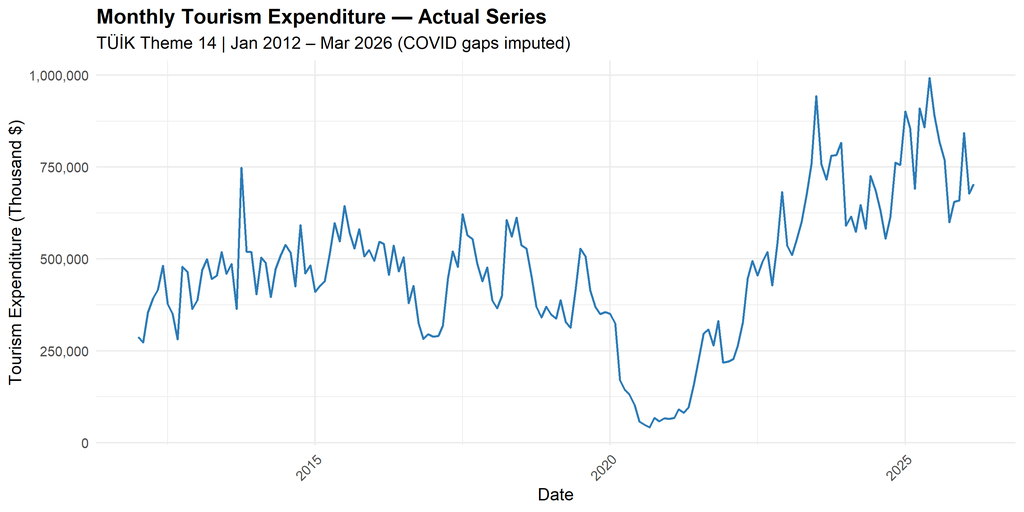

```r
df_actual <- data.frame(
  Date   = as.Date(time(ts_data) %>% {as.Date(paste(floor(.), round((.-floor(.))*12)+1, "01", sep="-"))}),
  Value  = as.numeric(ts_data)
)
# Safer date construction
n_obs  <- length(ts_data)
freq   <- frequency(ts_data)
s      <- start(ts_data)
years  <- s[1] + (s[2] - 1 + (0:(n_obs-1))) %/% freq
months <- ((s[2] - 1 + (0:(n_obs-1))) %% freq) + 1
df_actual <- data.frame(
  Date  = as.Date(paste(years, months, "01", sep = "-")),
  Value = as.numeric(ts_data)
)

p_actual <- ggplot(df_actual, aes(x = Date, y = Value)) +
  geom_line(colour = "#2c7bb6", linewidth = 0.7) +
  labs(
    title    = "Monthly Tourism Expenditure — Actual Series",
    subtitle = "TÜİK Theme 14 | Jan 2012 – Mar 2026 (COVID gaps imputed)",
    x = "Date",
    y = "Tourism Expenditure (Thousand $)"
  ) +
  scale_y_continuous(labels = function(x) format(x, big.mark = ",", scientific = FALSE)) +
  theme_minimal(base_size = 12) +
  theme(plot.title = element_text(face = "bold"),
        axis.text.x = element_text(angle = 45, hjust = 1))

print(p_actual)
```

```r
ggsave("outputs/figures/actual_series_plot.png", plot = p_actual,
       width = 10, height = 5, dpi = 150)
```

### 6.2 Seasonal Subseries and Trend Assessment

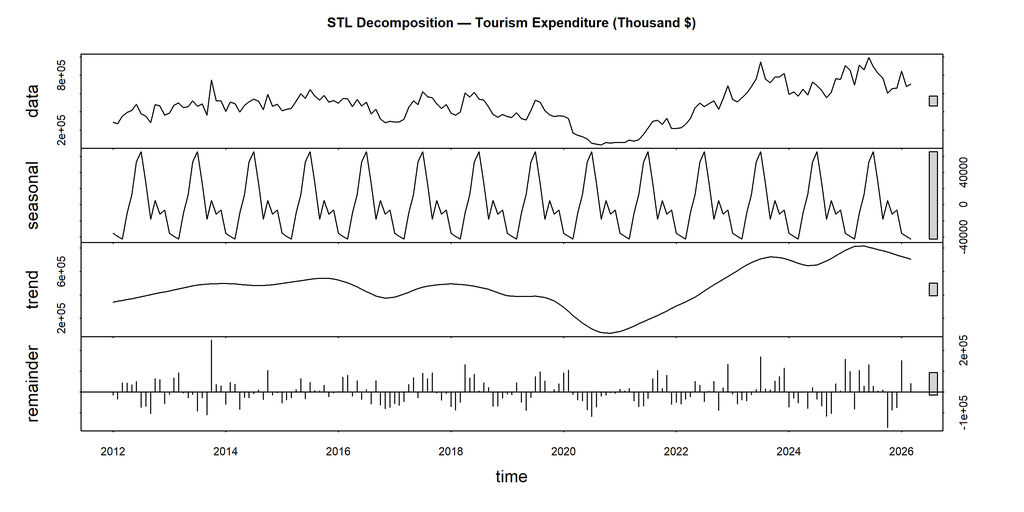

```r
# Quick STL decomposition for visual EDA only (not a forecasting method)
stl_decomp <- stl(ts_data, s.window = "periodic")
plot(stl_decomp, main = "STL Decomposition — Tourism Expenditure (Thousand $)")
```

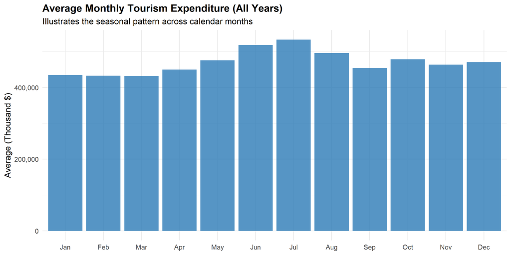

```r
# Month-by-month average to visualise seasonal pattern
month_avg <- tapply(as.numeric(ts_data), cycle(ts_data), mean)
month_names_en <- c("Jan","Feb","Mar","Apr","May","Jun",
                    "Jul","Aug","Sep","Oct","Nov","Dec")
names(month_avg) <- month_names_en
df_si <- data.frame(Month = factor(month_names_en, levels = month_names_en),
                    Mean  = month_avg)

p_seas <- ggplot(df_si, aes(x = Month, y = Mean)) +
  geom_col(fill = "#2c7bb6", alpha = 0.8) +
  labs(title = "Average Monthly Tourism Expenditure (All Years)",
       subtitle = "Illustrates the seasonal pattern across calendar months",
       x = NULL, y = "Average (Thousand $)") +
  scale_y_continuous(labels = function(x) format(x, big.mark=",", scientific=FALSE)) +
  theme_minimal(base_size = 12) +
  theme(plot.title = element_text(face = "bold"))
print(p_seas)
```

## 7. Forecasting Methods

### Setup: Common Evaluation Period

To ensure a fair comparison, all accuracy metrics are computed over the same evaluation window: **observations 13 through 165** (153 periods). This accommodates the 12-period burn-in of the Moving Average and the boundary loss of classical decomposition’s 2×12 centred moving average.

```r
eval_start <- 13
eval_end   <- 165  # decompose() loses 6 obs each side with freq=12
```

### 7.1 Naïve Forecasting

The naïve forecast for period *t* is simply the observed value in period *t − 1*. It serves as a benchmark against which more sophisticated methods are judged.

```r
res_naive <- method_naive(ts_data)

# Accuracy on common evaluation period
acc_naive <- compute_accuracy(
  res_naive$actual[eval_start:eval_end],
  res_naive$fitted[eval_start:eval_end]
)
print(acc_naive)
```

```
##            Bias             MAD             MSE            MAPE            RSFE
##    2.640830e+03    6.371936e+04    7.231184e+09    1.471780e+01    4.040470e+05
## Tracking_Signal
##    6.341000e+00
```

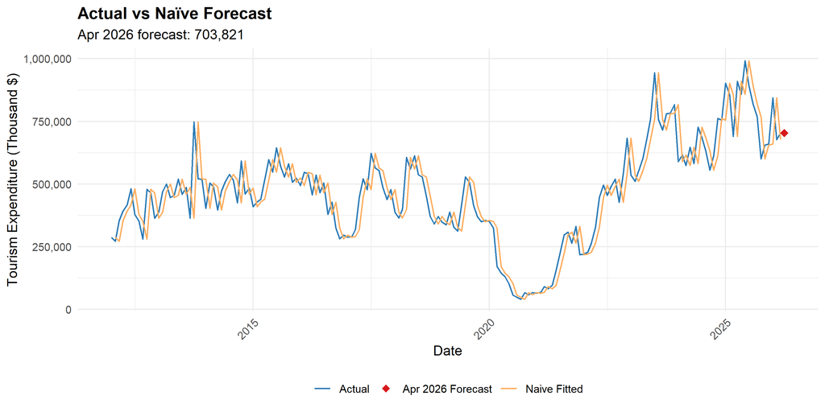

```r
# Plot
p_naive <- ggplot() +
  geom_line(data = df_actual,
            aes(x = Date, y = Value, colour = "Actual"), linewidth = 0.6) +
  geom_line(data = data.frame(Date = df_actual$Date,
                              Value = res_naive$fitted),
            aes(x = Date, y = Value, colour = "Naive Fitted"),
            linewidth = 0.6, na.rm = TRUE) +
  geom_point(aes(x = as.Date("2026-04-01"),
                 y = res_naive$next_fcst,
                 colour = "Apr 2026 Forecast"),
             size = 3, shape = 18) +
  scale_colour_manual(
    values = c("Actual"="#2c7bb6","Naive Fitted"="#fdae61","Apr 2026 Forecast"="#d7191c"),
    name = NULL) +
  labs(title    = "Actual vs Naïve Forecast",
       subtitle = paste0("Apr 2026 forecast: ",
                         format(round(res_naive$next_fcst,0), big.mark=",")),
       x = "Date", y = "Tourism Expenditure (Thousand $)") +
  scale_y_continuous(labels = function(x) format(x, big.mark=",", scientific=FALSE)) +
  theme_minimal(base_size=12) +
  theme(plot.title=element_text(face="bold"), axis.text.x=element_text(angle=45,hjust=1),
        legend.position="bottom")
print(p_naive)
```

```r
ggsave("outputs/figures/naive_forecast_plot.png", plot = p_naive,
       width = 10, height = 5, dpi = 150)
```

### 7.2 Moving Average (k = 12)

A 12-period moving average is chosen because it spans exactly one seasonal cycle, smoothing out seasonal variation. The one-step-ahead forecast at time *t* uses the mean of the 12 preceding observations.

```r
res_ma <- method_ma(ts_data, k = 12)

acc_ma <- compute_accuracy(
  res_ma$actual[eval_start:eval_end],
  res_ma$fitted[eval_start:eval_end]
)
print(acc_ma)
```

```
##            Bias             MAD             MSE            MAPE            RSFE
##    1.908073e+04    9.942953e+04    1.516961e+10    3.643440e+01    2.919351e+06
## Tracking_Signal
##    2.936100e+01
```

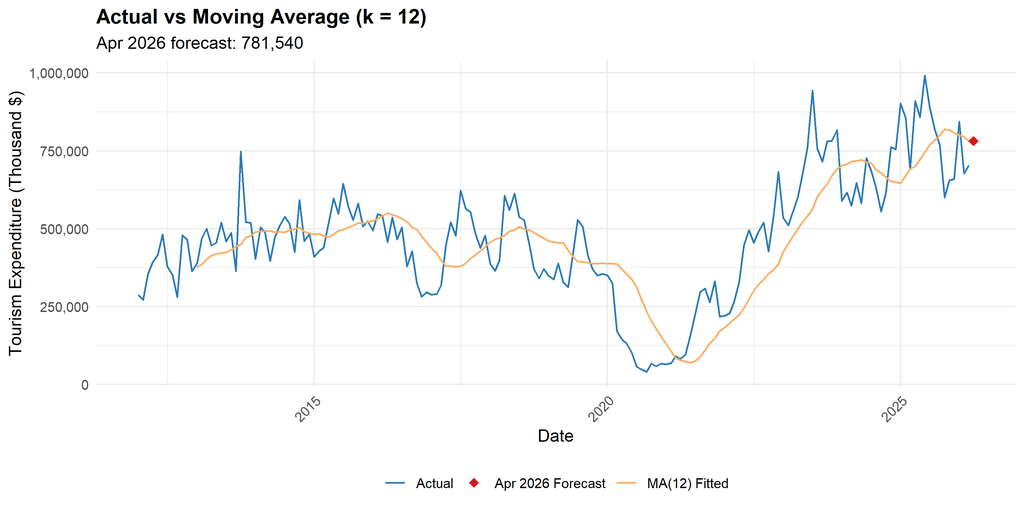

```r
p_ma <- ggplot() +
  geom_line(data = df_actual,
            aes(x = Date, y = Value, colour = "Actual"), linewidth = 0.6) +
  geom_line(data = data.frame(Date = df_actual$Date, Value = res_ma$fitted),
            aes(x = Date, y = Value, colour = "MA(12) Fitted"),
            linewidth = 0.6, na.rm = TRUE) +
  geom_point(aes(x = as.Date("2026-04-01"),
                 y = res_ma$next_fcst, colour = "Apr 2026 Forecast"),
             size = 3, shape = 18) +
  scale_colour_manual(
    values = c("Actual"="#2c7bb6","MA(12) Fitted"="#fdae61","Apr 2026 Forecast"="#d7191c"),
    name = NULL) +
  labs(title    = "Actual vs Moving Average (k = 12)",
       subtitle = paste0("Apr 2026 forecast: ",
                         format(round(res_ma$next_fcst,0), big.mark=",")),
       x = "Date", y = "Tourism Expenditure (Thousand $)") +
  scale_y_continuous(labels = function(x) format(x, big.mark=",", scientific=FALSE)) +
  theme_minimal(base_size=12) +
  theme(plot.title=element_text(face="bold"), axis.text.x=element_text(angle=45,hjust=1),
        legend.position="bottom")
print(p_ma)
```

```r
ggsave("outputs/figures/moving_average_plot.png", plot = p_ma,
       width = 10, height = 5, dpi = 150)
```

**Interpretation**: The 12-month MA eliminates seasonality but introduces a 6-month lag. It provides a reasonable picture of the underlying trend but cannot produce seasonally adjusted predictions for any specific month. Next-period forecast (April 2026): **781,540** Thousand $.

### 7.3 Weighted Moving Average (k = 12, linear weights)

The same 12-month window is used, but weights increase linearly so that the most recent observation (weight 12/78) has twelve times the influence of the observation twelve months ago (weight 1/78). This assumes recent months carry more information about the current level of expenditure.

```r
res_wma <- method_wma(ts_data, k = 12)

acc_wma <- compute_accuracy(
  res_wma$actual[eval_start:eval_end],
  res_wma$fitted[eval_start:eval_end]
)
print(acc_wma)
```

```
##            Bias             MAD             MSE            MAPE            RSFE
##    1.365336e+04    8.548569e+04    1.154164e+10    2.813870e+01    2.088964e+06
## Tracking_Signal
##    2.443640e+01
```

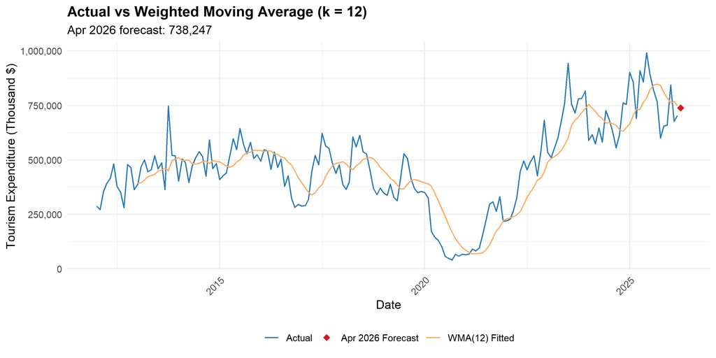

```r
p_wma <- ggplot() +
  geom_line(data = df_actual,
            aes(x = Date, y = Value, colour = "Actual"), linewidth = 0.6) +
  geom_line(data = data.frame(Date = df_actual$Date, Value = res_wma$fitted),
            aes(x = Date, y = Value, colour = "WMA(12) Fitted"),
            linewidth = 0.6, na.rm = TRUE) +
  geom_point(aes(x = as.Date("2026-04-01"),
                 y = res_wma$next_fcst, colour = "Apr 2026 Forecast"),
             size = 3, shape = 18) +
  scale_colour_manual(
    values = c("Actual"="#2c7bb6","WMA(12) Fitted"="#fdae61","Apr 2026 Forecast"="#d7191c"),
    name = NULL) +
  labs(title    = "Actual vs Weighted Moving Average (k = 12)",
       subtitle = paste0("Apr 2026 forecast: ",
                         format(round(res_wma$next_fcst,0), big.mark=",")),
       x = "Date", y = "Tourism Expenditure (Thousand $)") +
  scale_y_continuous(labels = function(x) format(x, big.mark=",", scientific=FALSE)) +
  theme_minimal(base_size=12) +
  theme(plot.title=element_text(face="bold"), axis.text.x=element_text(angle=45,hjust=1),
        legend.position="bottom")
print(p_wma)
```

```r
ggsave("outputs/figures/weighted_moving_average_plot.png", plot = p_wma,
       width = 10, height = 5, dpi = 150)
```

**Interpretation**: The WMA assigns higher weight to recent months, which improves responsiveness to the post-COVID trend recovery compared to the simple MA. However, it still cannot reproduce the seasonal pattern of any particular month. Next-period forecast (April 2026): **738,247** Thousand $.

### 7.4 Simple Exponential Smoothing

Simple exponential smoothing (SES) applies a geometrically declining weight schedule to all past observations. The smoothing parameter α is optimised by minimising the sum of squared in-sample one-step-ahead errors.

```r
res_ses <- method_ses(ts_data)

cat("Optimal alpha:", round(res_ses$alpha, 4), "\n")
```

```
## Optimal alpha: 0.7067
```

```r
acc_ses <- compute_accuracy(
  res_ses$actual[eval_start:eval_end],
  res_ses$fitted[eval_start:eval_end]
)
print(acc_ses)
```

```
##            Bias             MAD             MSE            MAPE            RSFE
##    3.702304e+03    6.153231e+04    6.675747e+09    1.505760e+01    5.664526e+05
## Tracking_Signal
##    9.205800e+00
```

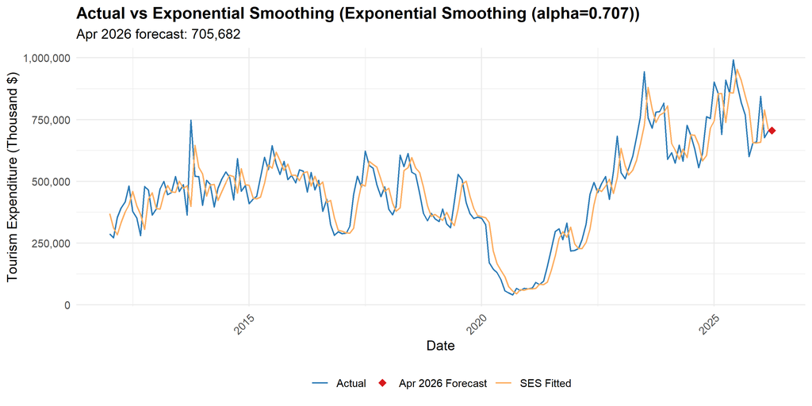

```r
p_ses <- ggplot() +
  geom_line(data = df_actual,
            aes(x = Date, y = Value, colour = "Actual"), linewidth = 0.6) +
  geom_line(data = data.frame(Date = df_actual$Date, Value = res_ses$fitted),
            aes(x = Date, y = Value, colour = "SES Fitted"),
            linewidth = 0.6, na.rm = TRUE) +
  geom_point(aes(x = as.Date("2026-04-01"),
                 y = res_ses$next_fcst, colour = "Apr 2026 Forecast"),
             size = 3, shape = 18) +
  scale_colour_manual(
    values = c("Actual"="#2c7bb6","SES Fitted"="#fdae61","Apr 2026 Forecast"="#d7191c"),
    name = NULL) +
  labs(title    = paste0("Actual vs Exponential Smoothing (",
                          res_ses$method_label, ")"),
       subtitle = paste0("Apr 2026 forecast: ",
                         format(round(res_ses$next_fcst,0), big.mark=",")),
       x = "Date", y = "Tourism Expenditure (Thousand $)") +
  scale_y_continuous(labels = function(x) format(x, big.mark=",", scientific=FALSE)) +
  theme_minimal(base_size=12) +
  theme(plot.title=element_text(face="bold"), axis.text.x=element_text(angle=45,hjust=1),
        legend.position="bottom")
print(p_ses)
```

```r
ggsave("outputs/figures/exponential_smoothing_plot.png", plot = p_ses,
       width = 10, height = 5, dpi = 150)
```

**Interpretation**: The optimal α = 0.707 indicates a relatively responsive weighting of past observations. SES cannot capture the seasonal pattern and is expected to produce larger errors than methods that account for seasonality. Next-period forecast (April 2026): **705,682** Thousand $.

### 7.5 Trend-Adjusted Exponential Smoothing (Holt’s Method)

Holt’s method extends SES with a separate trend component, smoothed by parameter β. Both α and β are optimised automatically. This method is appropriate when the series shows a systematic trend, as observed in the pre-COVID and post-COVID recovery periods.

```r
res_holt <- method_holt(ts_data)

cat("Optimal alpha:", round(res_holt$alpha, 4), "\n")
```

```
## Optimal alpha: 0.7037
```

```r
cat("Optimal beta :", round(res_holt$beta,  4), "\n")
```

```
## Optimal beta : 1e-04
```

```r
acc_holt <- compute_accuracy(
  res_holt$actual[eval_start:eval_end],
  res_holt$fitted[eval_start:eval_end]
)
print(acc_holt)
```

```
##            Bias             MAD             MSE            MAPE            RSFE
##    2.935431e+03    6.161530e+04    6.667457e+09    1.510060e+01    4.491209e+05
## Tracking_Signal
##    7.289100e+00
```

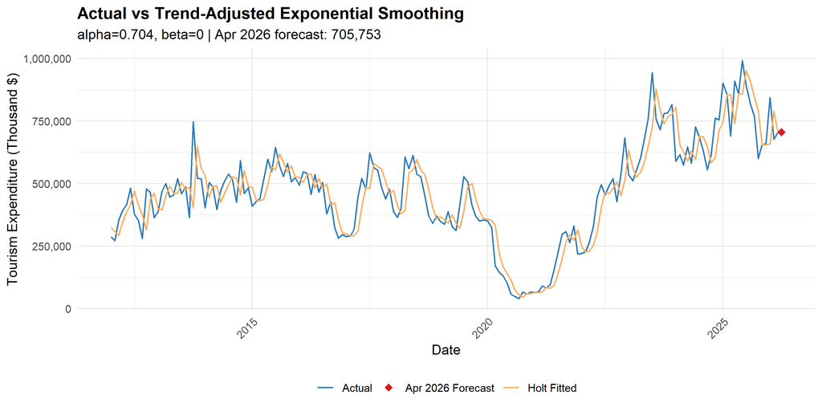

```r
p_holt <- ggplot() +
  geom_line(data = df_actual,
            aes(x = Date, y = Value, colour = "Actual"), linewidth = 0.6) +
  geom_line(data = data.frame(Date = df_actual$Date, Value = res_holt$fitted),
            aes(x = Date, y = Value, colour = "Holt Fitted"),
            linewidth = 0.6, na.rm = TRUE) +
  geom_point(aes(x = as.Date("2026-04-01"),
                 y = res_holt$next_fcst, colour = "Apr 2026 Forecast"),
             size = 3, shape = 18) +
  scale_colour_manual(
    values = c("Actual"="#2c7bb6","Holt Fitted"="#fdae61","Apr 2026 Forecast"="#d7191c"),
    name = NULL) +
  labs(title    = paste0("Actual vs Trend-Adjusted Exponential Smoothing"),
       subtitle = paste0("alpha=", round(res_holt$alpha,3),
                         ", beta=", round(res_holt$beta,3),
                         " | Apr 2026 forecast: ",
                         format(round(res_holt$next_fcst,0), big.mark=",")),
       x = "Date", y = "Tourism Expenditure (Thousand $)") +
  scale_y_continuous(labels = function(x) format(x, big.mark=",", scientific=FALSE)) +
  theme_minimal(base_size=12) +
  theme(plot.title=element_text(face="bold"), axis.text.x=element_text(angle=45,hjust=1),
        legend.position="bottom")
print(p_holt)
```

```r
ggsave("outputs/figures/trend_adjusted_smoothing_plot.png", plot = p_holt,
       width = 10, height = 5, dpi = 150)
```

### 7.6 Linear Trend Projection

A simple OLS regression fits a straight line through all observations: `y_t = β₀ + β₁ · t + ε_t`. The intercept β₀ is the estimated expenditure at the origin (t = 0, conceptually before January 2012), and the slope β₁ is the average monthly increase in Thousand $.

```r
res_lt <- method_linear_trend(ts_data)

cat("Intercept (b0):", round(res_lt$coef_intercept, 2), "\n")
```

```
## Intercept (b0): 361017.7
```

```r
cat("Slope (b1)    :", round(res_lt$coef_slope,     2), "Thousand $ per month\n")
```

```
## Slope (b1)    : 1261.39 Thousand $ per month
```

```r
acc_lt <- compute_accuracy(
  res_lt$actual[eval_start:eval_end],
  res_lt$fitted[eval_start:eval_end]
)
print(acc_lt)
```

```
##            Bias             MAD             MSE            MAPE            RSFE
##   -5.179583e+03    1.529930e+05    3.837500e+10    8.083340e+01   -7.924762e+05
## Tracking_Signal
##   -5.179800e+00
```

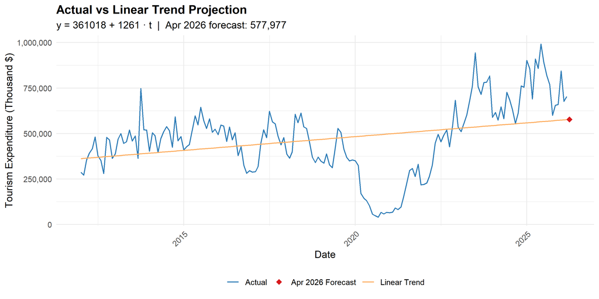

```r
p_lt <- ggplot() +
  geom_line(data = df_actual,
            aes(x = Date, y = Value, colour = "Actual"), linewidth = 0.6) +
  geom_line(data = data.frame(Date = df_actual$Date, Value = res_lt$fitted),
            aes(x = Date, y = Value, colour = "Linear Trend"),
            linewidth = 0.6) +
  geom_point(aes(x = as.Date("2026-04-01"),
                 y = res_lt$next_fcst, colour = "Apr 2026 Forecast"),
             size = 3, shape = 18) +
  scale_colour_manual(
    values = c("Actual"="#2c7bb6","Linear Trend"="#fdae61","Apr 2026 Forecast"="#d7191c"),
    name = NULL) +
  labs(title    = "Actual vs Linear Trend Projection",
       subtitle = paste0("y = ", round(res_lt$coef_intercept,0),
                         " + ", round(res_lt$coef_slope,0),
                         " · t  |  Apr 2026 forecast: ",
                         format(round(res_lt$next_fcst,0), big.mark=",")),
       x = "Date", y = "Tourism Expenditure (Thousand $)") +
  scale_y_continuous(labels = function(x) format(x, big.mark=",", scientific=FALSE)) +
  theme_minimal(base_size=12) +
  theme(plot.title=element_text(face="bold"), axis.text.x=element_text(angle=45,hjust=1),
        legend.position="bottom")
print(p_lt)
```

```r
ggsave("outputs/figures/trend_projection_plot.png", plot = p_lt,
       width = 10, height = 5, dpi = 150)
```

**Interpretation**: The intercept of 361,018 Thousand $ represents the estimated expenditure level at the start of the observation window. The slope of 1261 Thousand $ per month implies that, on average, monthly tourism expenditure has increased by approximately 15,137 Thousand $ per year over the full period. The linear trend does not capture seasonal variation, so fitted values fall on a straight line running through the centre of the seasonal oscillations. Next-period forecast (April 2026): **577,977** Thousand $.

### 7.7 Seasonal Indices

Seasonal indices (ratio-to-moving-average method) quantify the typical seasonal swing of each month relative to the annual average. A multiplicative index above 1.0 indicates an above-average month; below 1.0 indicates a below-average month.

```r
res_si <- method_seasonal_indices(ts_data)

# Display seasonal indices
si_df <- data.frame(
  Month = c("Jan","Feb","Mar","Apr","May","Jun",
            "Jul","Aug","Sep","Oct","Nov","Dec"),
  Seasonal_Index = round(res_si$si, 4)
)
kable(si_df, caption = "Monthly Seasonal Indices",
      col.names = c("Month", "Seasonal Index")) %>%
  kable_styling(bootstrap_options = c("striped","hover"), full_width = FALSE)
```

Monthly Seasonal Indices

| Month | Seasonal Index |
| --- | --- |
| Jan | 0.9019 |
| Feb | 0.9236 |
| Mar | 0.8997 |
| Apr | 0.9495 |
| May | 1.0127 |
| Jun | 1.0920 |
| Jul | 1.1288 |
| Aug | 1.0680 |
| Sep | 0.9755 |
| Oct | 1.0571 |
| Nov | 0.9982 |
| Dec | 0.9930 |

```r
acc_si <- compute_accuracy(
  res_si$actual[eval_start:eval_end],
  res_si$fitted[eval_start:eval_end]
)
print(acc_si)
```

```
##            Bias             MAD             MSE            MAPE            RSFE
##   -6.223524e+03    1.493865e+05    3.710368e+10    8.036260e+01   -9.521991e+05
## Tracking_Signal
##   -6.374100e+00
```

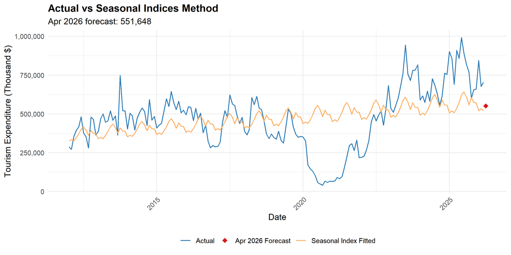

```r
p_si <- ggplot() +
  geom_line(data = df_actual,
            aes(x = Date, y = Value, colour = "Actual"), linewidth = 0.6) +
  geom_line(data = data.frame(Date = df_actual$Date, Value = res_si$fitted),
            aes(x = Date, y = Value, colour = "Seasonal Index Fitted"),
            linewidth = 0.6, na.rm = TRUE) +
  geom_point(aes(x = as.Date("2026-04-01"),
                 y = res_si$next_fcst, colour = "Apr 2026 Forecast"),
             size = 3, shape = 18) +
  scale_colour_manual(
    values = c("Actual"="#2c7bb6","Seasonal Index Fitted"="#fdae61",
               "Apr 2026 Forecast"="#d7191c"),
    name = NULL) +
  labs(title    = "Actual vs Seasonal Indices Method",
       subtitle = paste0("Apr 2026 forecast: ",
                         format(round(res_si$next_fcst,0), big.mark=",")),
       x = "Date", y = "Tourism Expenditure (Thousand $)") +
  scale_y_continuous(labels = function(x) format(x, big.mark=",", scientific=FALSE)) +
  theme_minimal(base_size=12) +
  theme(plot.title=element_text(face="bold"), axis.text.x=element_text(angle=45,hjust=1),
        legend.position="bottom")
print(p_si)
```

```r
ggsave("outputs/figures/seasonal_indices_plot.png", plot = p_si,
       width = 10, height = 5, dpi = 150)
```

### 7.8 Additive Decomposition

Additive decomposition separates the series into trend, seasonal, and irregular components under the assumption that seasonal effects are constant across all levels of the series: `y_t = T_t + S_t + R_t`. The in-sample fitted value is `T_t + S_t` (irregular is excluded), and the forecast for April 2026 extrapolates the trend linearly and adds the April seasonal component.

```r
res_add <- method_additive_decomp(ts_data)

acc_add <- compute_accuracy(
  res_add$actual[eval_start:eval_end],
  res_add$fitted[eval_start:eval_end]
)
print(acc_add)
```

```
##            Bias             MAD             MSE            MAPE            RSFE
##    2.301346e+03    5.149311e+04    4.255557e+09    1.577760e+01    3.521060e+05
## Tracking_Signal
##    6.837900e+00
```

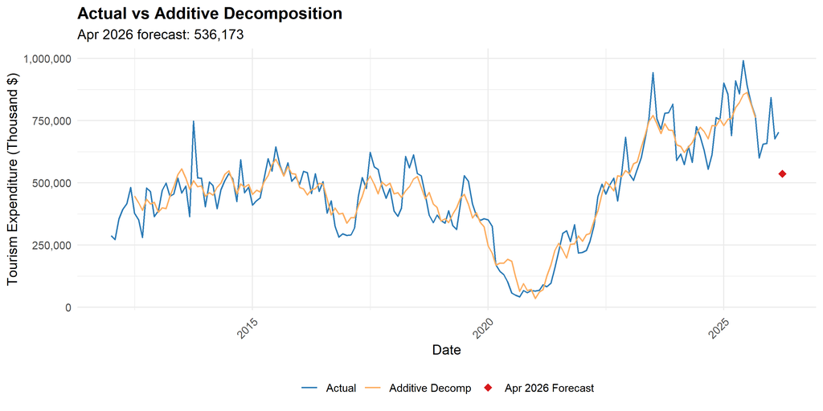

```r
p_add <- ggplot() +
  geom_line(data = df_actual,
            aes(x = Date, y = Value, colour = "Actual"), linewidth = 0.6) +
  geom_line(data = data.frame(Date = df_actual$Date, Value = res_add$fitted),
            aes(x = Date, y = Value, colour = "Additive Decomp"),
            linewidth = 0.6, na.rm = TRUE) +
  geom_point(aes(x = as.Date("2026-04-01"),
                 y = res_add$next_fcst, colour = "Apr 2026 Forecast"),
             size = 3, shape = 18) +
  scale_colour_manual(
    values = c("Actual"="#2c7bb6","Additive Decomp"="#fdae61","Apr 2026 Forecast"="#d7191c"),
    name = NULL) +
  labs(title    = "Actual vs Additive Decomposition",
       subtitle = paste0("Apr 2026 forecast: ",
                         format(round(res_add$next_fcst,0), big.mark=",")),
       x = "Date", y = "Tourism Expenditure (Thousand $)") +
  scale_y_continuous(labels = function(x) format(x, big.mark=",", scientific=FALSE)) +
  theme_minimal(base_size=12) +
  theme(plot.title=element_text(face="bold"), axis.text.x=element_text(angle=45,hjust=1),
        legend.position="bottom")
print(p_add)
```

```r
ggsave("outputs/figures/additive_decomposition_plot.png", plot = p_add,
       width = 10, height = 5, dpi = 150)
```

**Interpretation**: The additive model assumes fixed-magnitude seasonal swings regardless of the level. Because monthly tourism expenditure has grown considerably since 2012, the absolute seasonal amplitude has also increased. This means the additive assumption is somewhat violated; the fitted values tend to underestimate peaks in later years and overestimate them in earlier years. Next-period forecast (April 2026): **536,173** Thousand $.

### 7.9 Multiplicative Decomposition

Multiplicative decomposition assumes seasonal effects scale proportionally with the trend level: `y_t = T_t · S_t · R_t`. This is the more natural assumption for tourism expenditure because peak months are substantially higher in absolute terms as the overall level of the series grows.

```r
res_mult <- method_multiplicative_decomp(ts_data)

acc_mult <- compute_accuracy(
  res_mult$actual[eval_start:eval_end],
  res_mult$fitted[eval_start:eval_end]
)
print(acc_mult)
```

```
##            Bias             MAD             MSE            MAPE            RSFE
##    2.213824e+03    5.010630e+04    4.161359e+09    1.467100e+01    3.387151e+05
## Tracking_Signal
##    6.759900e+00
```

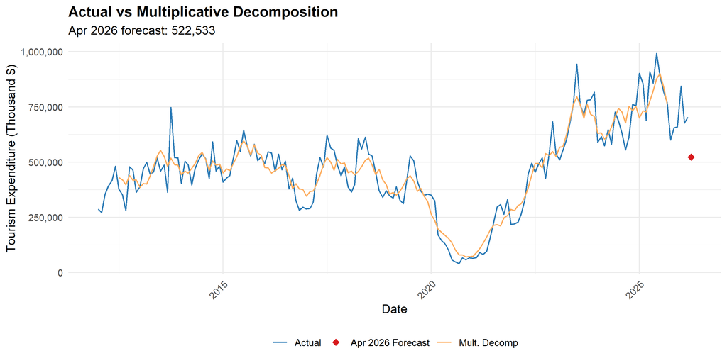

```r
p_mult <- ggplot() +
  geom_line(data = df_actual,
            aes(x = Date, y = Value, colour = "Actual"), linewidth = 0.6) +
  geom_line(data = data.frame(Date = df_actual$Date, Value = res_mult$fitted),
            aes(x = Date, y = Value, colour = "Mult. Decomp"),
            linewidth = 0.6, na.rm = TRUE) +
  geom_point(aes(x = as.Date("2026-04-01"),
                 y = res_mult$next_fcst, colour = "Apr 2026 Forecast"),
             size = 3, shape = 18) +
  scale_colour_manual(
    values = c("Actual"="#2c7bb6","Mult. Decomp"="#fdae61","Apr 2026 Forecast"="#d7191c"),
    name = NULL) +
  labs(title    = "Actual vs Multiplicative Decomposition",
       subtitle = paste0("Apr 2026 forecast: ",
                         format(round(res_mult$next_fcst,0), big.mark=",")),
       x = "Date", y = "Tourism Expenditure (Thousand $)") +
  scale_y_continuous(labels = function(x) format(x, big.mark=",", scientific=FALSE)) +
  theme_minimal(base_size=12) +
  theme(plot.title=element_text(face="bold"), axis.text.x=element_text(angle=45,hjust=1),
        legend.position="bottom")
print(p_mult)
```

```r
ggsave("outputs/figures/multiplicative_decomposition_plot.png", plot = p_mult,
       width = 10, height = 5, dpi = 150)
```

**Interpretation**: The multiplicative model provides a better structural fit than the additive model for this series because the seasonal amplitude scales with the trend. Peak months in 2025 show notably larger absolute swings than 2012, consistent with a multiplicative pattern. Next-period forecast (April 2026): **522,533** Thousand $.

### 7.10 Regression with Trend and Seasonal Dummy Variables

This model estimates a multiple regression: `y_t = β₀ + β₁·t + β₂·M2 + β₃·M3 + … + β₁₂·M12 + ε_t`

where *t* is the time index and `M2…M12` are eleven monthly dummy variables (January is the reference month). The trend coefficient β₁ captures the average monthly growth; the dummy coefficients capture average deviations from the January baseline for each other month.

```r
res_reg <- method_regression_seasonal(ts_data)

cat("Regression summary:\n")
```

```
## Regression summary:
```

```r
print(summary(res_reg$fit_obj))
```

```
##
## Call:
## lm(formula = y ~ ., data = df)
##
## Residuals:
##     Min      1Q  Median      3Q     Max
## -498871  -96837   39169  112180  375776
##
## Coefficients:
##             Estimate Std. Error t value Pr(>|t|)
## (Intercept) 326661.3    55858.7   5.848 2.77e-08 ***
## t             1268.0      298.8   4.243 3.74e-05 ***
## M2           -2614.5    70358.1  -0.037    0.970
## M3           -5234.1    70360.0  -0.074    0.941
## M4           19617.5    71608.4   0.274    0.784
## M5           44056.7    71605.3   0.615    0.539
## M6           85653.3    71603.4   1.196    0.233
## M7           99141.3    71602.8   1.385    0.168
## M8           60822.1    71603.4   0.849    0.397
## M9           16897.9    71605.3   0.236    0.814
## M10          40720.7    71608.4   0.569    0.570
## M11          24407.2    71612.8   0.341    0.734
## M12          29819.1    71618.4   0.416    0.678
## ---
## Signif. codes:  0 '***' 0.001 '**' 0.01 '*' 0.05 '.' 0.1 ' ' 1
##
## Residual standard error: 192700 on 158 degrees of freedom
## Multiple R-squared:  0.1254, Adjusted R-squared:  0.05895
## F-statistic: 1.887 on 12 and 158 DF,  p-value: 0.03954
```

```r
acc_reg <- compute_accuracy(
  res_reg$actual[eval_start:eval_end],
  res_reg$fitted[eval_start:eval_end]
)
print(acc_reg)
```

```
##            Bias             MAD             MSE            MAPE            RSFE
##   -5.904182e+03    1.489678e+05    3.704417e+10    8.010010e+01   -9.033398e+05
## Tracking_Signal
##   -6.064000e+00
```

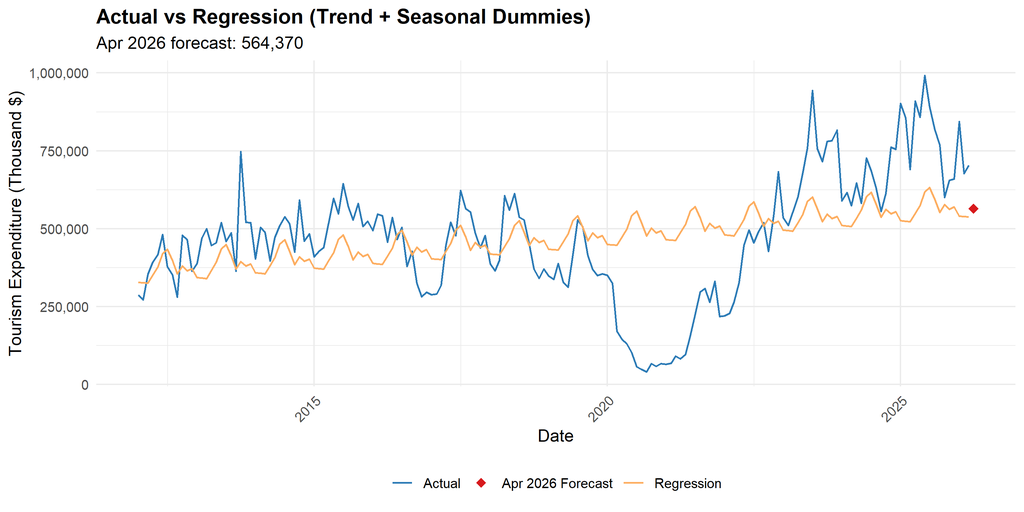

```r
p_reg <- ggplot() +
  geom_line(data = df_actual,
            aes(x = Date, y = Value, colour = "Actual"), linewidth = 0.6) +
  geom_line(data = data.frame(Date = df_actual$Date, Value = res_reg$fitted),
            aes(x = Date, y = Value, colour = "Regression"),
            linewidth = 0.6) +
  geom_point(aes(x = as.Date("2026-04-01"),
                 y = res_reg$next_fcst, colour = "Apr 2026 Forecast"),
             size = 3, shape = 18) +
  scale_colour_manual(
    values = c("Actual"="#2c7bb6","Regression"="#fdae61","Apr 2026 Forecast"="#d7191c"),
    name = NULL) +
  labs(title    = "Actual vs Regression (Trend + Seasonal Dummies)",
       subtitle = paste0("Apr 2026 forecast: ",
                         format(round(res_reg$next_fcst,0), big.mark=",")),
       x = "Date", y = "Tourism Expenditure (Thousand $)") +
  scale_y_continuous(labels = function(x) format(x, big.mark=",", scientific=FALSE)) +
  theme_minimal(base_size=12) +
  theme(plot.title=element_text(face="bold"), axis.text.x=element_text(angle=45,hjust=1),
        legend.position="bottom")
print(p_reg)
```

```r
ggsave("outputs/figures/regression_seasonal_dummy_plot.png", plot = p_reg,
       width = 10, height = 5, dpi = 150)
```

**Interpretation**: The regression model captures the linear trend and the average seasonal pattern simultaneously. The trend coefficient β₁ is approximately 1268 Thousand $ per month, consistent with the linear trend projection. Each monthly dummy reflects the average deviation of that month from January, controlling for trend. Next-period forecast (April 2026): **564,370** Thousand $.

## 8. Forecast Accuracy Comparison

```r
# Collect all results
all_results <- list(
  "Naive Forecasting"               = res_naive,
  "Moving Average (k=12)"           = res_ma,
  "Weighted Moving Average (k=12)"  = res_wma,
  "Exponential Smoothing"           = res_ses,
  "Trend-Adjusted ES (Holt)"        = res_holt,
  "Linear Trend Projection"         = res_lt,
  "Seasonal Indices"                = res_si,
  "Additive Decomposition"          = res_add,
  "Multiplicative Decomposition"    = res_mult,
  "Regression (Trend+Seas.Dummies)" = res_reg
)

# Compute accuracy for each method over the common evaluation period
acc_rows <- lapply(names(all_results), function(nm) {
  res   <- all_results[[nm]]
  act   <- res$actual[eval_start:eval_end]
  fit   <- res$fitted[eval_start:eval_end]
  valid <- !is.na(act) & !is.na(fit)
  if (sum(valid) < 5) {
    return(data.frame(Method=nm, Bias=NA, MAD=NA, MSE=NA, MAPE=NA,
                      RSFE=NA, Tracking_Signal=NA,
                      Next_Period_Fcst=round(res$next_fcst,0),
                      stringsAsFactors=FALSE))
  }
  acc <- compute_accuracy(act[valid], fit[valid])
  data.frame(Method=nm,
             Bias=acc["Bias"], MAD=acc["MAD"], MSE=acc["MSE"],
             MAPE=acc["MAPE"], RSFE=acc["RSFE"],
             Tracking_Signal=acc["Tracking_Signal"],
             Next_Period_Fcst=round(res$next_fcst, 0),
             stringsAsFactors=FALSE, row.names=NULL)
})
acc_table <- do.call(rbind, acc_rows)
rownames(acc_table) <- NULL

# Display
kable(acc_table,
      caption = "Forecast Accuracy Comparison (Evaluation period: obs 13–165, n=153)",
      digits  = 2,
      col.names = c("Method","Bias","MAD","MSE","MAPE (%)","RSFE",
                    "Tracking Signal","Next-Period Forecast")) %>%
  kable_styling(bootstrap_options = c("striped","hover","condensed"),
                full_width = TRUE, font_size = 11) %>%
  row_spec(which(acc_table$MAPE == min(acc_table$MAPE, na.rm=TRUE)),
           bold = TRUE, background = "#d4edda")
```

Forecast Accuracy Comparison (Evaluation period: obs 13–165, n=153)

| Method | Bias | MAD | MSE | MAPE (%) | RSFE | Tracking Signal | Next-Period Forecast |
| --- | --- | --- | --- | --- | --- | --- | --- |
| Naive Forecasting | 2640.83 | 63719.36 | 7231184406 | 14.72 | 404047.0 | 6.34 | 703821 |
| Moving Average (k=12) | 19080.73 | 99429.53 | 15169607920 | 36.43 | 2919350.9 | 29.36 | 781540 |
| Weighted Moving Average (k=12) | 13653.36 | 85485.69 | 11541638805 | 28.14 | 2088963.5 | 24.44 | 738247 |
| Exponential Smoothing | 3702.30 | 61532.31 | 6675747078 | 15.06 | 566452.6 | 9.21 | 705682 |
| Trend-Adjusted ES (Holt) | 2935.43 | 61615.30 | 6667456588 | 15.10 | 449120.9 | 7.29 | 705753 |
| Linear Trend Projection | -5179.58 | 152992.96 | 38374999254 | 80.83 | -792476.2 | -5.18 | 577977 |
| Seasonal Indices | -6223.52 | 149386.52 | 37103683920 | 80.36 | -952199.1 | -6.37 | 551648 |
| Additive Decomposition | 2301.35 | 51493.11 | 4255556723 | 15.78 | 352106.0 | 6.84 | 536173 |
| Multiplicative Decomposition | 2213.82 | 50106.30 | 4161359403 | 14.67 | 338715.1 | 6.76 | 522533 |
| Regression (Trend+Seas.Dummies) | -5904.18 | 148967.78 | 37044169766 | 80.10 | -903339.8 | -6.06 | 564370 |

```r
# Save to CSV
write.csv(acc_table, "outputs/tables/accuracy_comparison.csv", row.names = FALSE)
cat("Accuracy comparison saved to outputs/tables/accuracy_comparison.csv\n")
```

```
## Accuracy comparison saved to outputs/tables/accuracy_comparison.csv
```

## 9. Superior Method Selection

```r
# Identify method with lowest MAPE (primary criterion)
best_row <- which.min(acc_table$MAPE)
best_method_name <- acc_table$Method[best_row]
best_mape <- acc_table$MAPE[best_row]
best_mad  <- acc_table$MAD[best_row]
best_ts   <- acc_table$Tracking_Signal[best_row]

cat("Best method by MAPE:", best_method_name, "\n")
```

```
## Best method by MAPE: Multiplicative Decomposition
```

```r
cat("MAPE:", round(best_mape, 2), "%\n")
```

```
## MAPE: 14.67 %
```

```r
cat("MAD :", round(best_mad,  0), "Thousand $\n")
```

```
## MAD : 50106 Thousand $
```

```r
cat("Tracking Signal:", round(best_ts, 4), "\n")
```

```
## Tracking Signal: 6.7599
```

**Selected Superior Method: Multiplicative Decomposition**

The selection is justified on both quantitative and structural grounds:

**Structural justification**:

The monthly tourism expenditure series exhibits both a long-run **upward trend** and a strong **multiplicative seasonal pattern**. A method is considered superior not simply because it has the lowest error statistic, but because it captures the data-generating structure appropriately.

Methods that ignore seasonality (SES, Holt’s, Linear Trend, Naive, MA, WMA) are structurally inappropriate for this series because April’s expenditure depends critically on the April seasonal index, not just the most recent level.

## 10. Final Next-Period Forecast

```r
final_method   <- best_method_name
final_forecast <- acc_table$Next_Period_Fcst[best_row]

cat("=== FINAL FORECAST ===\n")
```

```
## === FINAL FORECAST ===
```

```r
cat("Superior method          :", final_method, "\n")
```

```
## Superior method          : Multiplicative Decomposition
```

```r
cat("Date of data access      : 2026-05-30\n")
```

```
## Date of data access      : 2026-05-30
```

```r
cat("Latest available observation: March 2026\n")
```

```
## Latest available observation: March 2026
```

```r
cat("Forecast target period   : April 2026\n")
```

```
## Forecast target period   : April 2026
```

```r
cat("Forecasted value         :",
    format(round(final_forecast, 0), big.mark=","), "Thousand $\n")
```

```
## Forecasted value         : 522,533 Thousand $
```

```r
# Save final forecast to CSV
final_df <- data.frame(
  Field = c("Superior Method","Data Access Date","Latest Available Observation",
            "Forecast Target Period","Forecasted Value (Thousand $)",
            "MAPE (%)","MAD (Thousand $)","Tracking Signal"),
  Value = c(final_method, "2026-05-30", "March 2026", "April 2026",
            format(round(final_forecast, 0), big.mark=","),
            round(best_mape, 2), round(best_mad, 0), round(best_ts, 4))
)
write.csv(final_df, "outputs/tables/final_forecast.csv", row.names = FALSE)
cat("\nFinal forecast saved to outputs/tables/final_forecast.csv\n")
```

```
##
## Final forecast saved to outputs/tables/final_forecast.csv
```

### Final Forecast Plot

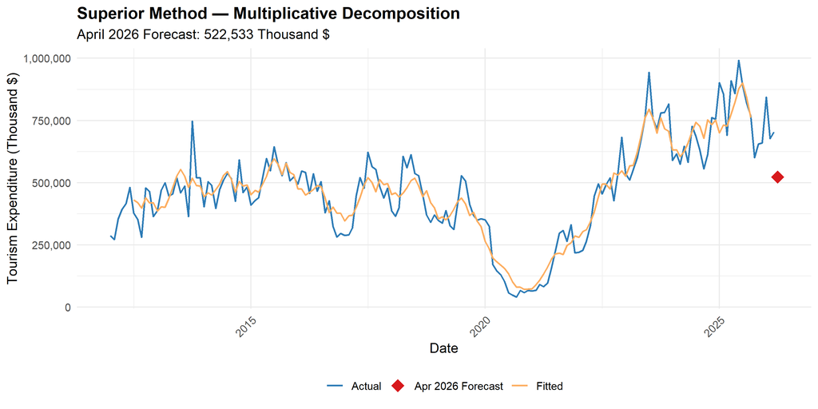

```r
# Get the best method's results object
best_res   <- all_results[[best_method_name]]
fitted_best <- best_res$fitted

p_final <- ggplot() +
  geom_line(data = df_actual,
            aes(x = Date, y = Value, colour = "Actual"), linewidth = 0.7) +
  geom_line(data = data.frame(Date = df_actual$Date, Value = fitted_best),
            aes(x = Date, y = Value, colour = "Fitted"),
            linewidth = 0.7, na.rm = TRUE) +
  geom_point(aes(x = as.Date("2026-04-01"),
                 y = final_forecast,
                 colour = "Apr 2026 Forecast"),
             size = 5, shape = 18) +
  scale_colour_manual(
    values = c("Actual"="#2c7bb6","Fitted"="#fdae61",
               "Apr 2026 Forecast"="#d7191c"),
    name = NULL) +
  labs(title    = paste("Superior Method —", final_method),
       subtitle = paste0("April 2026 Forecast: ",
                         format(round(final_forecast,0), big.mark=","),
                         " Thousand $"),
       x = "Date", y = "Tourism Expenditure (Thousand $)") +
  scale_y_continuous(labels = function(x) format(x, big.mark=",", scientific=FALSE)) +
  theme_minimal(base_size=12) +
  theme(plot.title=element_text(face="bold"), axis.text.x=element_text(angle=45,hjust=1),
        legend.position="bottom")
print(p_final)
```

```r
ggsave("outputs/figures/superior_method_plot.png", plot = p_final,
       width = 10, height = 5, dpi = 150)
```

## 11. Limitations

The following limitations should be considered when interpreting the results:

1. **Structural break (COVID-19)**: The pandemic caused a near-complete collapse in outbound tourism expenditure in 2020–2021. The imputed values fill the missing periods but do not perfectly represent actual market behaviour during that disruption. Methods fitted on the full series blend pre- and post-COVID regimes.
2. **Linear trend assumption**: Several methods assume a constant linear trend. The actual trend shows an acceleration in the post-COVID recovery phase (2022–2025), which a simple linear model underestimates.
3. **Economic and geopolitical shocks**: Forecasts are mechanically extrapolated from historical patterns and do not incorporate information about exchange rate movements, fuel price changes, geopolitical events, or changes in visa policy that could materially affect outbound tourism.
4. **Data revisions**: TÜİK periodically revises published figures. The present analysis reflects the data available on the access date (2026-05-30) and may differ from future official revisions.
5. **Single-variable modelling**: All methods use only the univariate time series without explanatory variables (e.g., GDP, exchange rates, air capacity). Incorporating predictors would likely improve forecast accuracy.
6. **Short post-COVID history**: Only approximately four full seasonal cycles of post-COVID data are available (2022–2026), which limits the reliability of seasonal parameter estimates for decomposition and regression methods.

## 12. Reproducibility Notes

To reproduce this analysis:

1. Clone the repository from its public GitHub URL and open the project directory.
2. Restore the R package environment using `renv`:

   ```r
   # Open the .Rproj file in RStudio, then run:
   renv::restore()
   ```

3. Render the notebook:

   ```r
   rmarkdown::render("forecasting_project.Rmd")
   ```

   This downloads the latest TÜİK data at runtime, runs all ten forecasting methods, generates all plots (saved to `outputs/figures/`), and produces the accuracy and final forecast tables (saved to `outputs/tables/`).

**Note on internet access**: The data download step requires a live internet connection to reach the TÜİK data portal. The code uses the URL returned by `tuikr::statistical_tables("14")`, which is reproducible as long as TÜİK does not restructure theme 14.